# TextAnalysis - MYP reports S1 2014-2015

FdR

3 March 2015

After downloading the .csv file from Managebac about the semester 1 report for the 2014-2015 academic year, we have copied-paste all the comments into a .txt file ready for text analysis (aka text mining).

Because text analysis is case sensitive, we put everything into lower case, we then remove all punctuation signs, we then also remove all the **stopwords**. Stopwords are all the common words like: is, he, she, I , and, etc. Finally we also remove all the extra space that are unecessary.

This already strip the comments from a lots of noise.  
Although reading them doesn’t flow as well, the comments now look like this

```
## <<VCorpus (documents: 3, metadata (corpus/indexed): 0/0)>>
##
## [[1]]
## <<PlainTextDocument (metadata: 7)>>
## alexandra greatly benefit participating actively speaking activities give opportunity practise creating language spontaneously receive constructive feedback future improvement also review complex grammar points regular basis seek help encounters difficulties
##
## [[2]]
## <<PlainTextDocument (metadata: 7)>>
## fabio friendly member group regularly contributes class discussion participates actively group investigations lines reasoning concise logical complete able select apply appropriate inquiry mathematical problem solving techniques familiar unfamiliar situations
##
## [[3]]
## <<PlainTextDocument (metadata: 7)>>
## zena progressing well ideas original works hard edit hand revised pieces narrative well organised engaging read discursive piece lacked detail facts inaccurate continues work improving analysis vocabulary writers techniques
```

Let’s see the 30 most frequently used words in this S1 reports comments. On top is the word, and the number below it is how many timed that word appeared in the comments.

```
##         class          work          well        skills          time
##           901           794           503           359           319
##          good       improve         ideas   assignments         needs
##           317           276           272           269           248
##          will         group       working   discussions understanding
##           247           246           210           197           193
##           can          also         peers   participant      learning
##           188           187           184           181           177
##    activities           new          next          help       student
##           174           168           158           152           152
##        effort        others       writing       benefit          unit
##           149           149           149           147           147
```

A wordle would be quite nice to display in a visually more appealing way these frequent words. So let’s build one for all words that appears 60 or more times on all the comments.

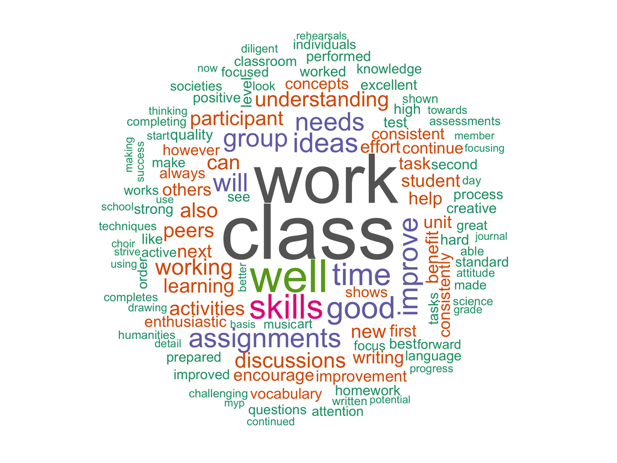

Now, with the wordle (which displays over 100 words), one can see that some words that are quite similar in meaning are appearing more than once; for instance: *make*, *making* or *improves*, *improving*, or again *discuss* and *discussion*. There is a function in text mining to stem the words. By stemming our corpus, we can now redo our working our high frequency words.

```
##       work      class     improv       well      skill       time
##       1205        907        576        503        414        376
##   particip      activ       need       good     assign       idea
##        333        329        322        317        301        286
##       will    complet    consist      group understand    continu
##        282        268        267        261        258        257
##      focus       task    discuss      learn    perform       peer
##        249        244        227        212        204        196
##       help     effort    student        can       show       also
##        194        192        191        188        188        187
```

Now we can really see education related concepts on top of that list.

Another thing one can do with text mining is to check how one concept is related (associated) to other concepts. I have chosen the top 3 concepts for this:

```
## $work
##   allevi  anxieti     hard     test      day    allot   narrat   finish
##     0.25     0.25     0.23     0.21     0.20     0.19     0.19     0.18
##    group   analys  complet     edit     hand   school    humor   manner
##     0.18     0.17     0.17     0.17     0.17     0.17     0.16     0.16
## principl
##     0.16
##
## $class
##  particip     pride   discuss     music contribut     often   creativ
##      0.30      0.21      0.20      0.20      0.19      0.18      0.17
##  encourag    french    within
##      0.16      0.16      0.16
##
## $improv
##            can        forward           look          drill            fit
##           0.42           0.37           0.37           0.31           0.30
##         second       calendar        success         overal          human
##           0.29           0.27           0.27           0.26           0.24
##          adequ        deadlin          forth          begin        continu
##           0.23           0.23           0.23           0.22           0.21
##          first     particular activitiesskil         domain         especi
##           0.21           0.21           0.20           0.20           0.20
##      managebac           sinc         involv          check          cours
##           0.20           0.20           0.19           0.18           0.18
##          manag            one      strongest       classmat           load
##           0.18           0.18           0.18           0.17           0.17
##      managabac         simpli            two          decis           near
##           0.17           0.17           0.17           0.16           0.16
##            sit          upcom
##           0.16           0.16
```

Now finding association on report comments is a really skew process due to the fact that many teacher copy paste almost the same comments for many students. An example of this is the concepts associated with the word *student*.

```
##             student
## humor          0.34
## principl       0.34
## openmind       0.31
## demeanor       0.29
## pleasant       0.21
## leader         0.17
## appreci        0.16
## capabl         0.16
## best           0.15
## contributor    0.15
## alway          0.14
## dedic          0.14
## exampl         0.14
## readili        0.14
## solver         0.14
## fellow         0.13
## request        0.13
## wellmotiv      0.13
## bit            0.12
## cooper         0.12
## fun            0.11
## includ         0.11
## much           0.11
## obvious        0.11
## talk           0.11
```

The first 3 words *humor*, *principl* and *openmind* seems to have the highest association with the concept of *student*, but at looking at the reports, it all comes from one particular teacher who copied-pasted the same phrases over and over.